# Weekly Energy Charts

December 09, 2022

Sign up to receive our email updates via [Substack](https://leach.substack.com/)

[interactive chart not shown]

# Featured Stories

## Keystone Spill

#### [Andrew Leach](https://linkedin.com/leach-econ)

[Well, that’s not good](https://www.cbc.ca/news/business/keystone-pipeline-1.6680590).

TC Energy has confirmed that it is dealing with a 14,000 barrel (yes, 14,000 barrel) leak on the Keystone pipeline, with oil having entered a creek in Kansas.

This is at least the third major spill on the Keystone line, with previous incidents in 2017 and 2019.

This is also one of the largest oil spills from a pipeline in recent US history. In 2013, a Tesoro line spilled over 20,000 barrels and, in another incident well-known to oil sands watchers, an Enbridge pipeline also spilled more than 20,000 barrels in Michigan in 2010.

Hoping that the impact is limited.

## Remote Community Diesel

#### [Marc Vermette](https://www.linkedin.com/in/marc-vermette/)

Many communities in Nunavut and other remote regions in Canada remain completely dependent on diesel for electricity and heating.

This results in energy systems that are expensive, unreliable, and a major source of pollution. For example, the pollution rate from electricity generation within Nunavut is [8 times higher](https://www.qec.nu.ca/power-nunavut/renewable-energy) than the national average.

The Canadian government plans on [eliminating diesel-powered generation](https://www.pembina.org/blog/tracking-diesel-reduction-progress-remote-communities) in these remote communities by 2030.

However, many experts claim this goal is out of reach given the current progress towards the infrastructure needed to accomplish it.

There are 200+ remote communities in Canada that aren’t connected to the electricity grid.

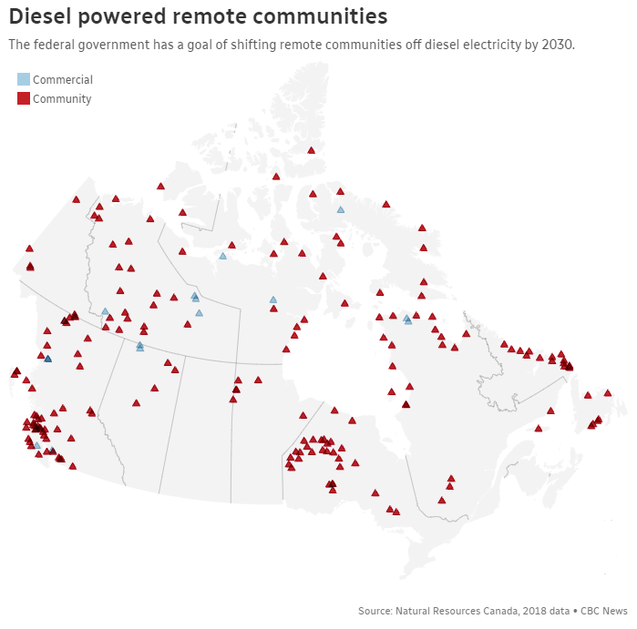

Power producers and residents have reservations about a switch to renewable energy. This has to change, says [Ian Gates](https://www.researchgate.net/publication/357418934_Why_is_it_so_difficult_to_replace_diesel_in_Nunavut_Canada), an expert in the field.

[Original Article](https://www.iea.org/news/renewable-power-s-growth-is-being-turbocharged-as-countries-seek-to-strengthen-energy-security)

## Cenovus 2023 Forecast

#### [Erica Beattie](https://www.linkedin.com/in/erica-beattie-594b471a1/?originalSubdomain=ca)

Earlier this week, Canada’s Cenovus Energy Inc. announced its [2023 budget](https://www.cenovus.com/News-and-Stories/News-releases/2022/2568065), which forecasts a higher capital expenditure for the upcoming year. The energy producer expects an increase of more than 3% in total upstream production of barrels of oil - between 800,000 and 840,000 barrels of oil equivalent/day. In terms of spending, Cenovus anticipates 2023 capital spend to be between $4 billion to $4.5 billion - a significant increase from this year’s budget of between $3.3 and $3.7 billion.

The Calgary Herald published an article discussing Cenovus’ budget and outlining the global energy industry factors that are driving this increase in spending. A significant one that many are aware of, is the invasion of major oil exporter Russia over Ukraine. This further limited already tight supplies, resulting in an increase in crude oil prices of up to 79% this year. To amplify these limitations, as of Monday December 5, the Eupean Union banned Russian crude imports.

Echoing Cenovus’ message, [Suncor Energy](https://www.reuters.com/business/energy/suncor-energy-forecasts-higher-spend-2023-2022-11-29/) and [Canadian Natural Resources](https://financialpost.com/commodities/energy/oil-gas/canadian-natural-resources-forecasts-higher-production) have also stated a prediction of higher capital expenditure in the new year. Energy producers are feeling the pressure of today’s industry, especially with rising costs and shortages of both labour and materials, and we will see these pressures reflected in prices.

## Momentum from the Energy Crisis

#### [Marc Vermette](https://www.linkedin.com/in/marc-vermette/)

The ongoing international energy crisis has caused an explosion in the acceleration of renewable energy adoption.

The world is on track to add a similar amount of renewable energy capacity in the next 5 years that it did in the previous 20.

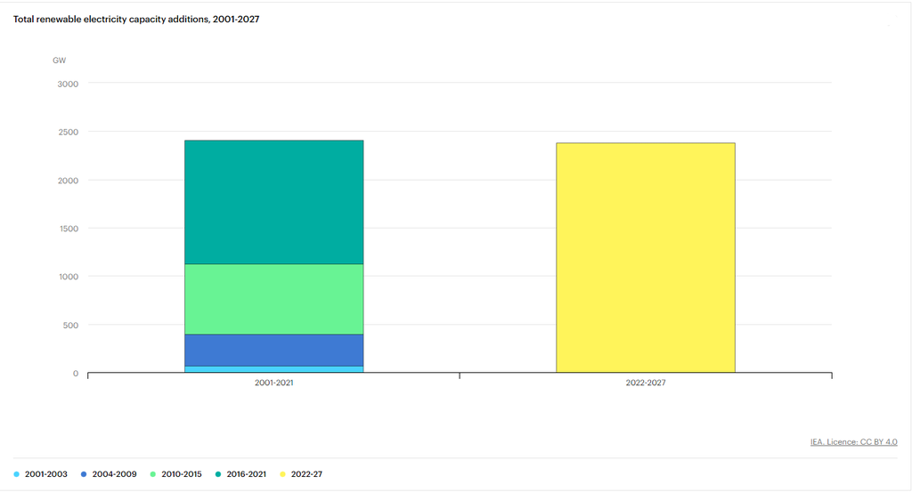

This increase is 30% higher than the growth that was forecasted last year, showcasing the power of governments taking action throughout the energy crisis.

In the next 5 years, renewable energy capacity is expected to double, potentially sustaining the 1.5°C goal that was [previously thought dead](https://www.bloomberg.com/news/articles/2022-11-08/is-the-1-5c-warming-goal-dead-cop27-and-climate-overshoot).

“This is a clear example of how the current energy crisis can be a historic turning point towards a cleaner and more secure energy [future],” said IEA executive director Fatih Birol.

[Original Article](https://www.iea.org/news/renewable-power-s-growth-is-being-turbocharged-as-countries-seek-to-strengthen-energy-security)

# Oil

## Weekly Crude Prices

### Feature Crude

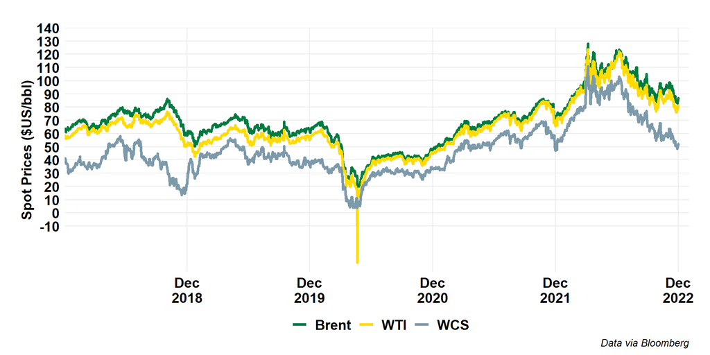

### Alberta Crude

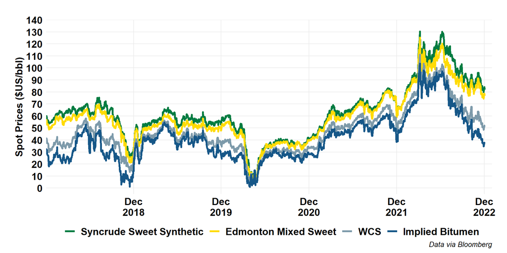

### Alberta Crude (Short)

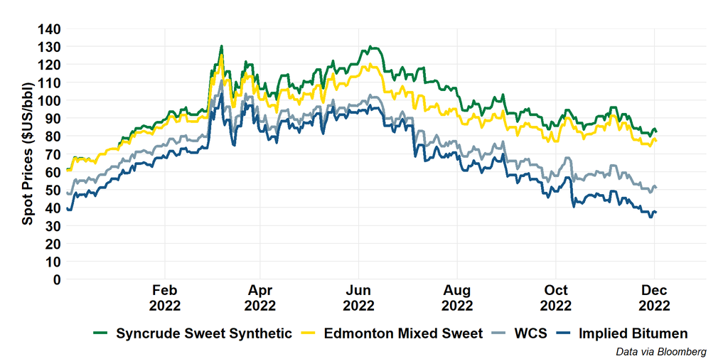

### US Crude

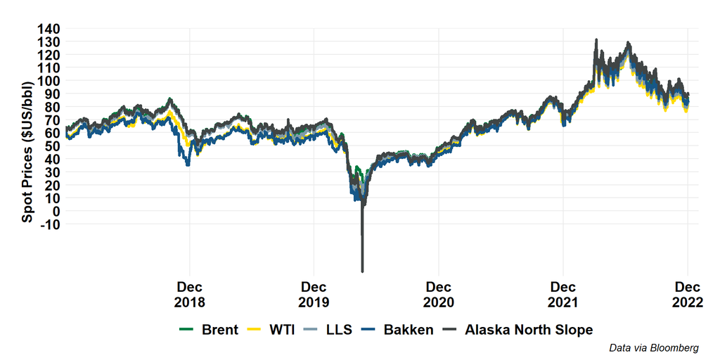

### Global Crude

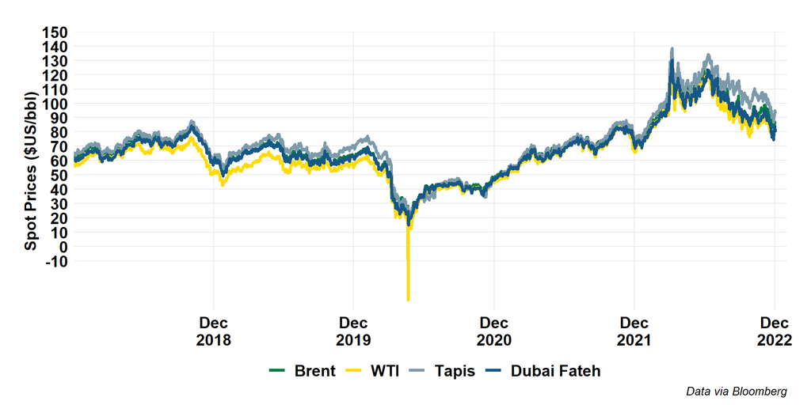

## Oil Price Differentials

### Brent-WTI

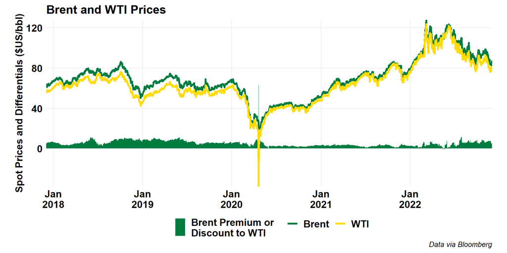

### WTI-WCS

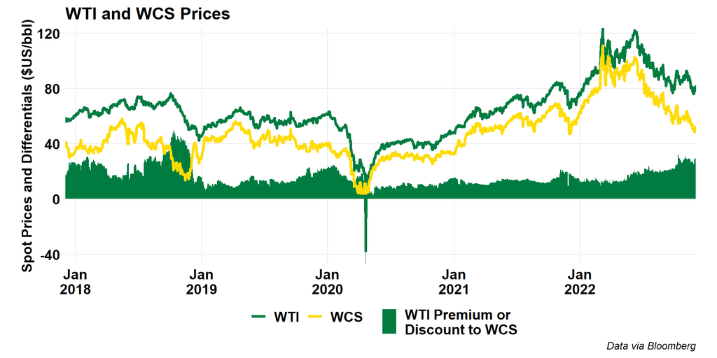

### WTI-WCS (Short)

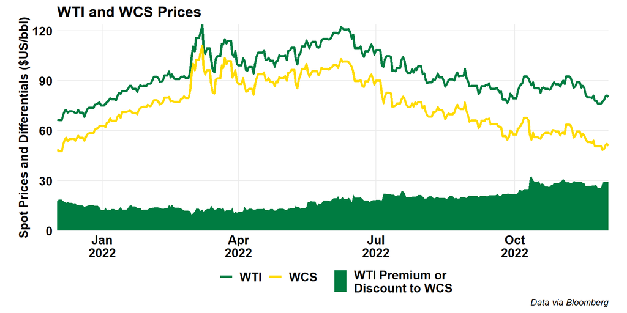

### Maya-WCS

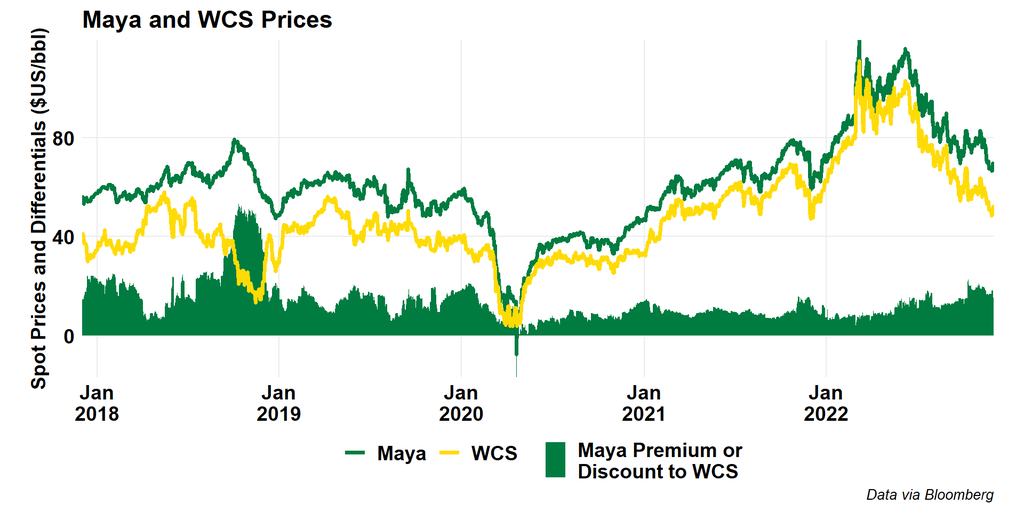

### WTI Cushing vs MEH

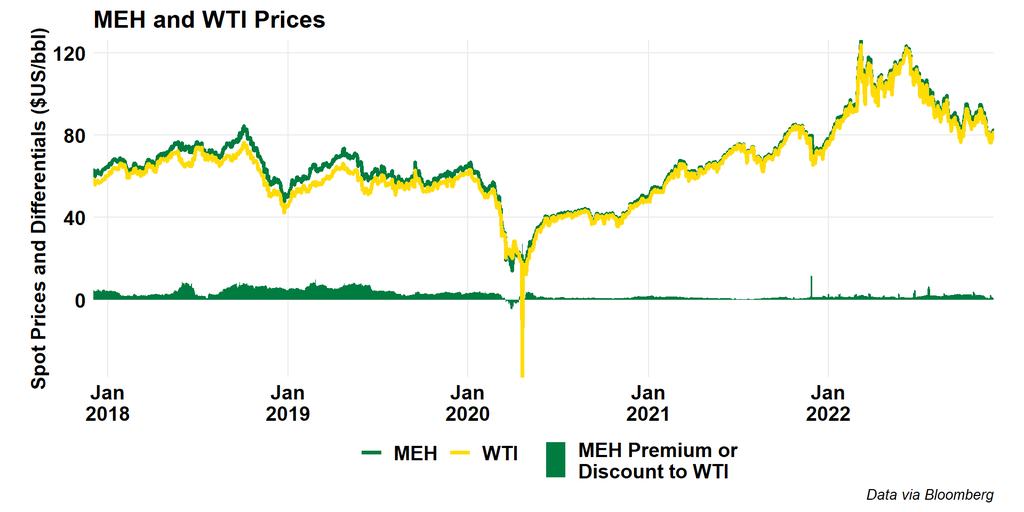

## Forward Curves

### WTI

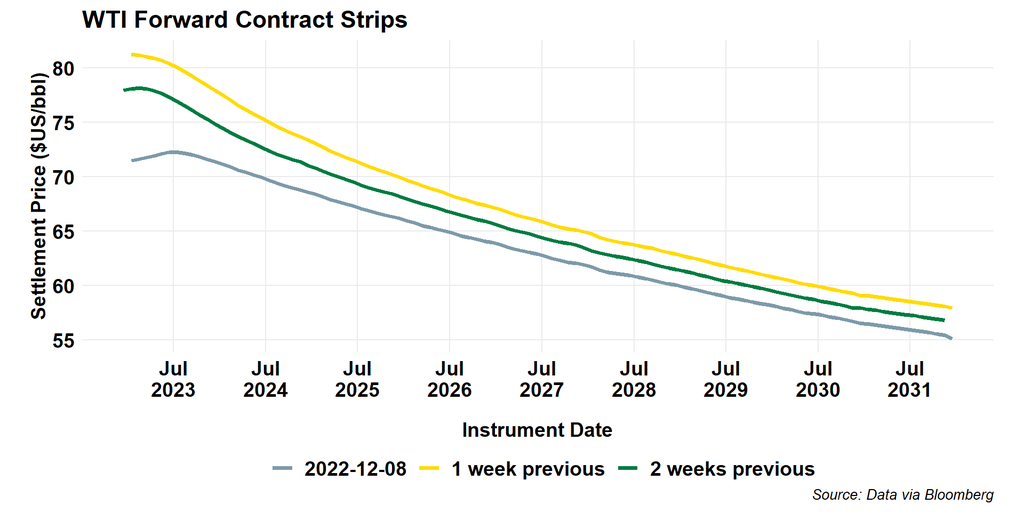

### Brent

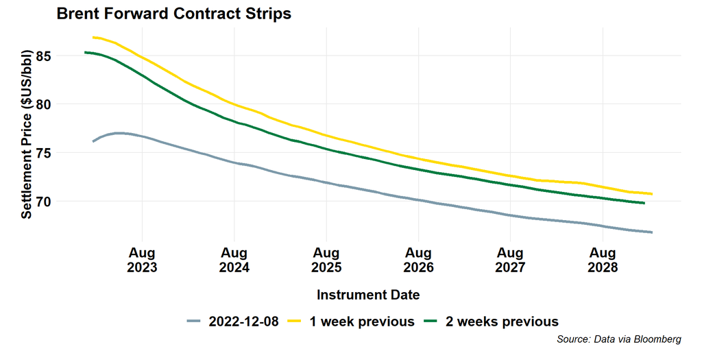

## Canadian Crude Supply and Disposition

### Canadian Production

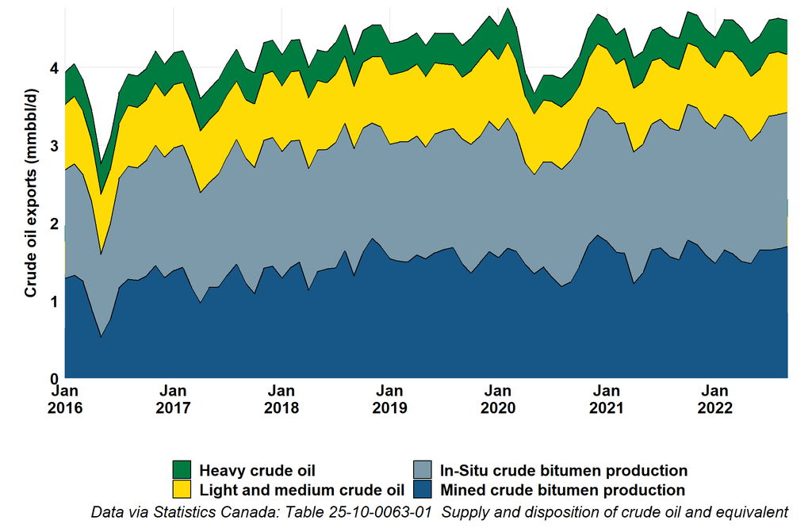

### Alberta Production

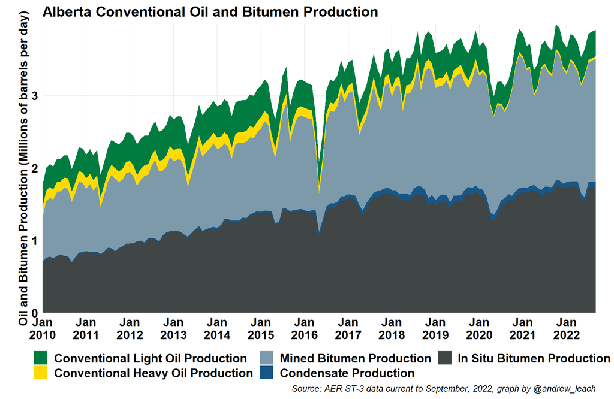

### Imports

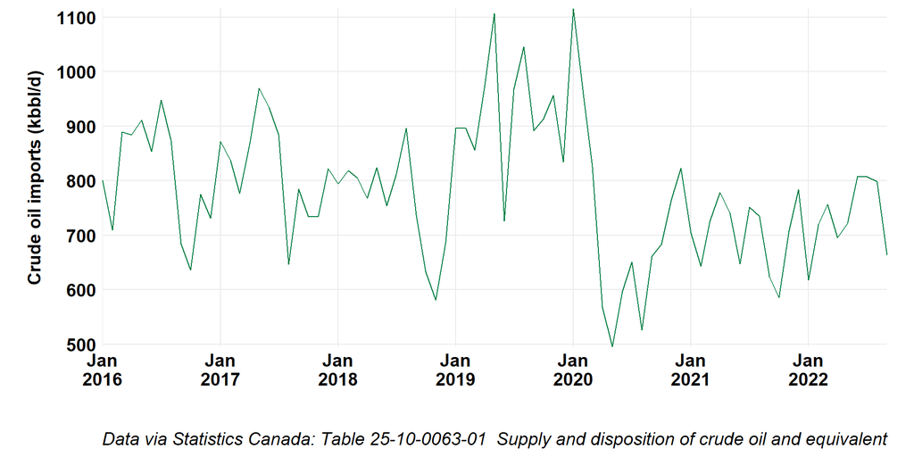

### Exports

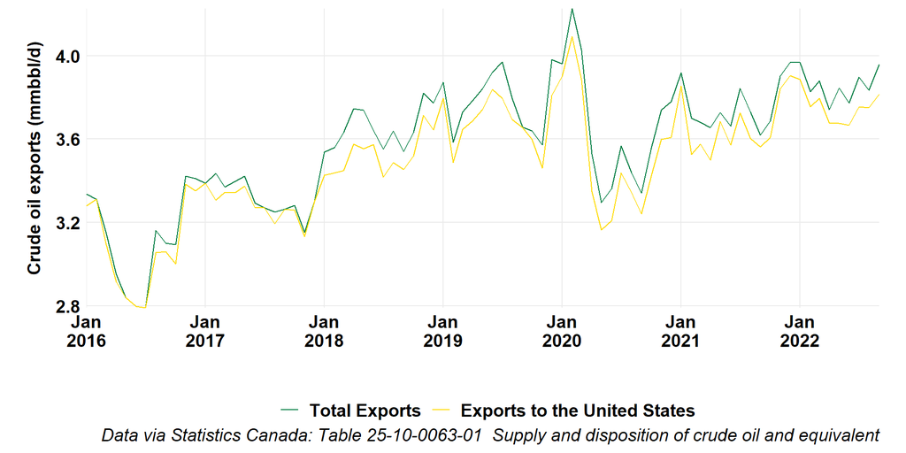

### Exports by Rail

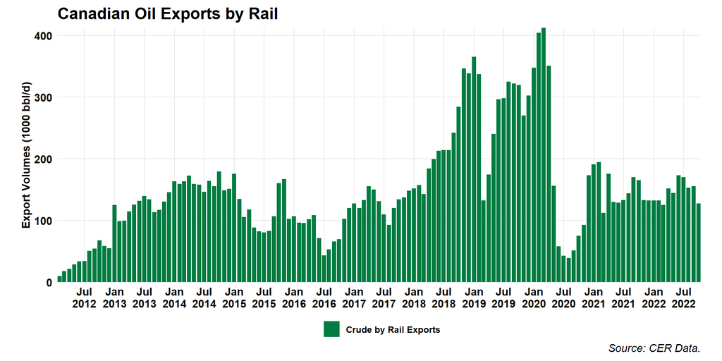

## US Oil

### Production

### LTO Production by Play

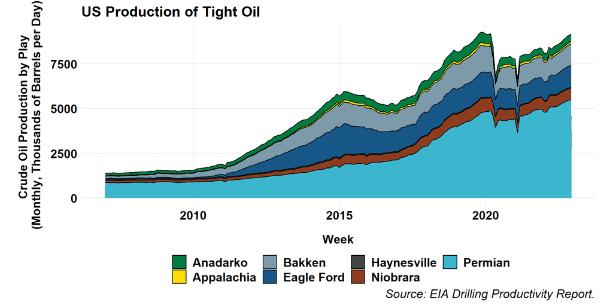

### EIA STEO Forecasts

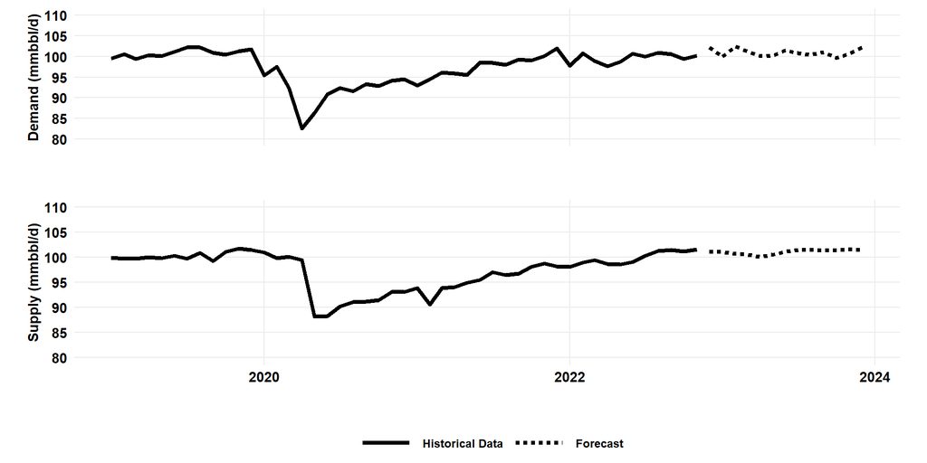

# Refined Products

## Canadian Gasoline Prices

### Map

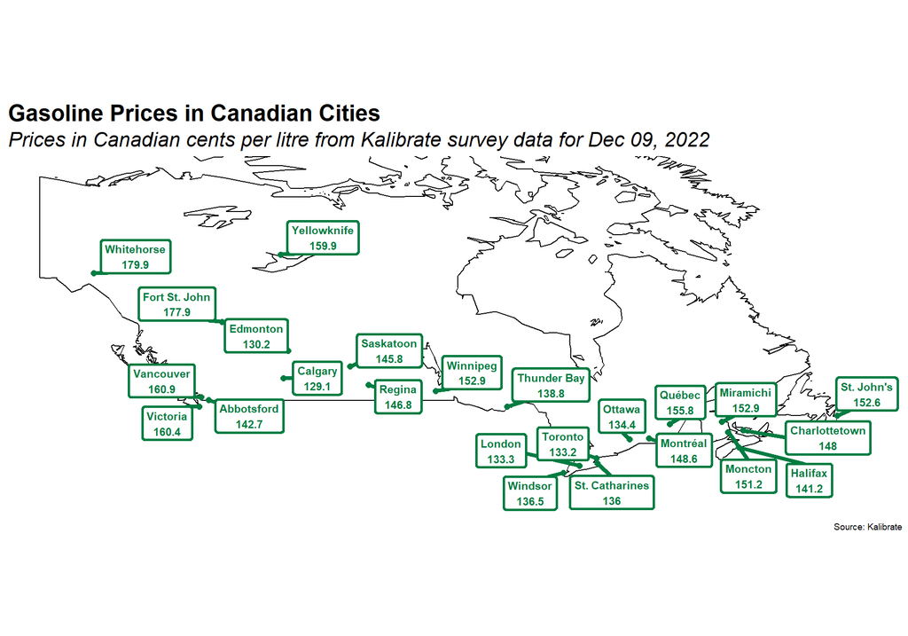

### Historic Gasoline Prices

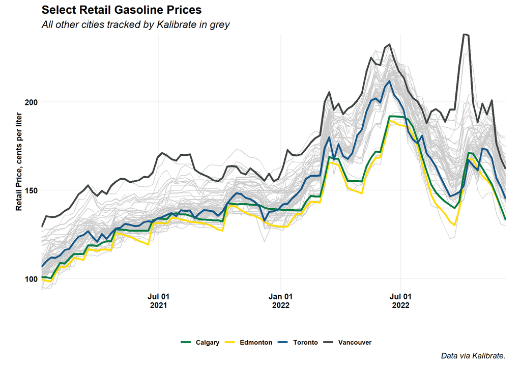

### Gasoline Prices in BTC

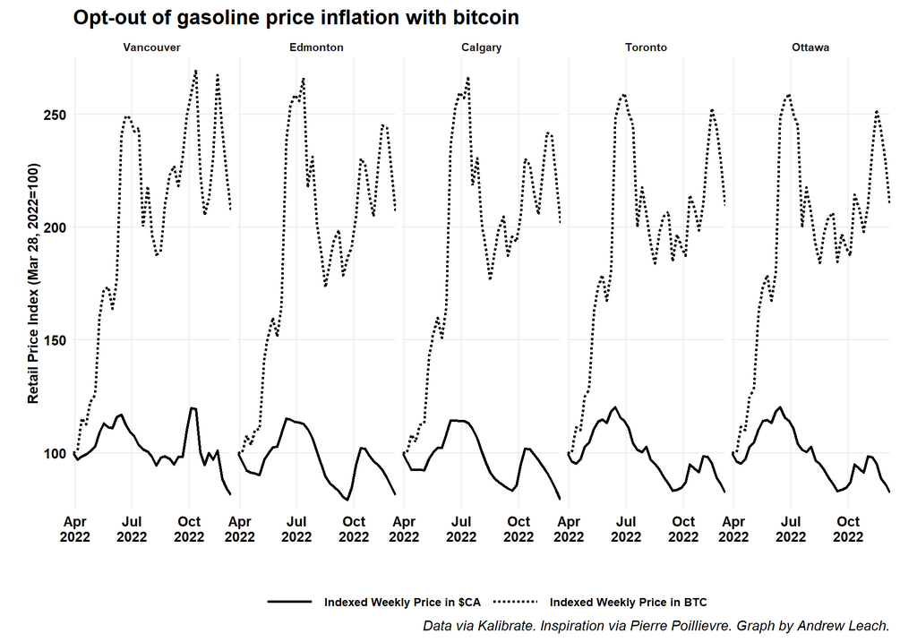

### Historic Diesel Prices

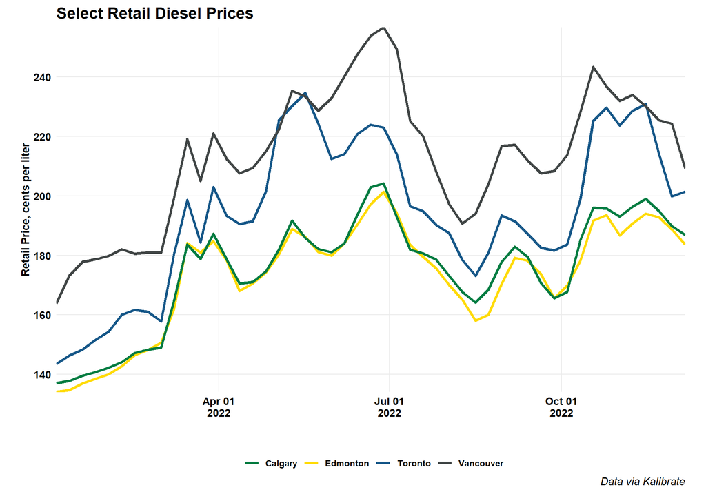

### Diesel Prices in BTC

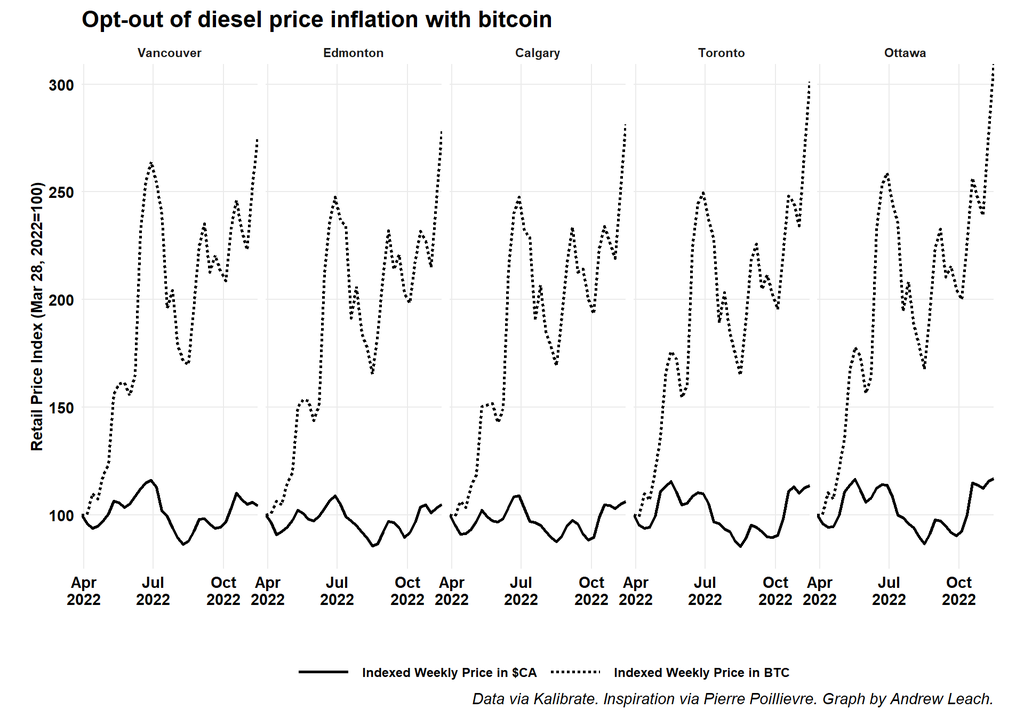

## Canadian Refinery Runs

### Canadian Refinery Runs

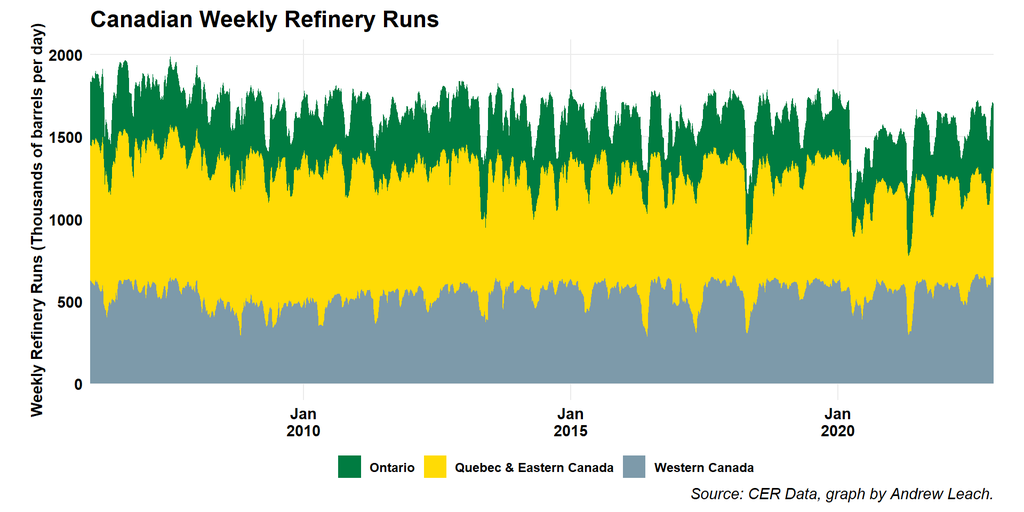

### Western Canada Refinery Runs

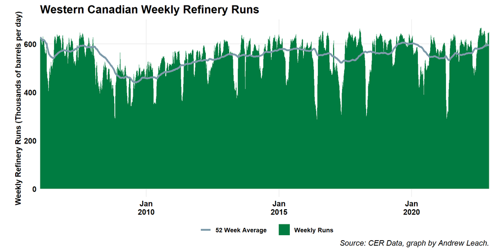

# Natural Gas

## Natural Gas Market Summary

### Feature Gas

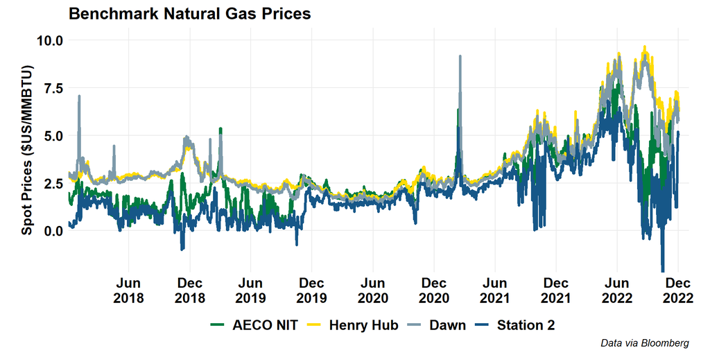

### Feature Gas (Short)

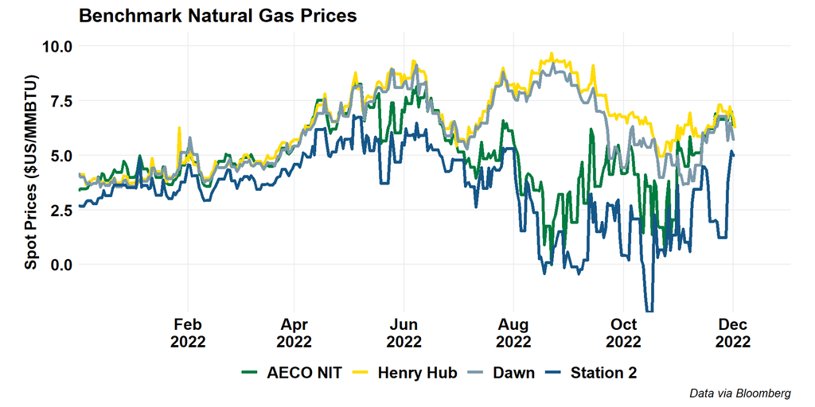

### Global Gas

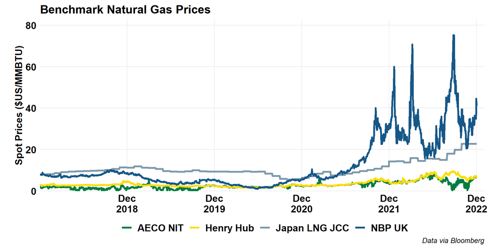